# Clustering and classification

25 Nov 2018

# Clustering and classification (Week 4)

## Read Data

```r
library("readxl")
library("ggplot2")
library("data.table")
library("dplyr")
library("stringr")
library("tidyr")
library("GGally")
library("ggplot2")
library("MASS")
library("corrplot")
data("Boston")
```

### Description of data

```r
glimpse(Boston)
```

```
## Observations: 506
## Variables: 14
## $ crim    <dbl> 0.00632, 0.02731, 0.02729, 0.03237, 0.06905, 0.02985, ...
## $ zn      <dbl> 18.0, 0.0, 0.0, 0.0, 0.0, 0.0, 12.5, 12.5, 12.5, 12.5,...
## $ indus   <dbl> 2.31, 7.07, 7.07, 2.18, 2.18, 2.18, 7.87, 7.87, 7.87, ...
## $ chas    <int> 0, 0, 0, 0, 0, 0, 0, 0, 0, 0, 0, 0, 0, 0, 0, 0, 0, 0, ...
## $ nox     <dbl> 0.538, 0.469, 0.469, 0.458, 0.458, 0.458, 0.524, 0.524...
## $ rm      <dbl> 6.575, 6.421, 7.185, 6.998, 7.147, 6.430, 6.012, 6.172...
## $ age     <dbl> 65.2, 78.9, 61.1, 45.8, 54.2, 58.7, 66.6, 96.1, 100.0,...
## $ dis     <dbl> 4.0900, 4.9671, 4.9671, 6.0622, 6.0622, 6.0622, 5.5605...
## $ rad     <int> 1, 2, 2, 3, 3, 3, 5, 5, 5, 5, 5, 5, 5, 4, 4, 4, 4, 4, ...
## $ tax     <dbl> 296, 242, 242, 222, 222, 222, 311, 311, 311, 311, 311,...
## $ ptratio <dbl> 15.3, 17.8, 17.8, 18.7, 18.7, 18.7, 15.2, 15.2, 15.2, ...
## $ black   <dbl> 396.90, 396.90, 392.83, 394.63, 396.90, 394.12, 395.60...
## $ lstat   <dbl> 4.98, 9.14, 4.03, 2.94, 5.33, 5.21, 12.43, 19.15, 29.9...
## $ medv    <dbl> 24.0, 21.6, 34.7, 33.4, 36.2, 28.7, 22.9, 27.1, 16.5, ...
```

#### The dataset contains a total of 506 cases with 14 attributes/variables for each case of the dataset.They are:

#### crim - per capita crime rate by town

#### zn - proportion of residential land zoned for lots over 25,000 sq.ft.

#### indus - proportion of non-retail business acres per town.

#### chas - Charles River dummy variable (1 if tract bounds river; 0 otherwise)

#### nox - nitric oxides concentration (parts per 10 million)

#### rm - average number of rooms per dwelling

#### age - proportion of owner-occupied units built prior to 1940

#### dis - weighted distances to five Boston employment centres

#### rad - index of accessibility to radial highways

#### tax - full-value property-tax rate per $10,000

#### ptratio - pupil-teacher ratio by town

#### black - 1000(Bk - 0.63)^2 where Bk is the proportion of blacks by town

#### lstat - % lower status of the population

#### medv - Median value of owner-occupied homes in $1000’s

#### A curios feature of the dataset seems to be variable 14 (“medv”), which has the median value of ownder-occupied homes. Now that dataset has many values pegged exactly at 50k dollars which could be a case of censoring since a good deal of variability is seen at other median values of “medv”.

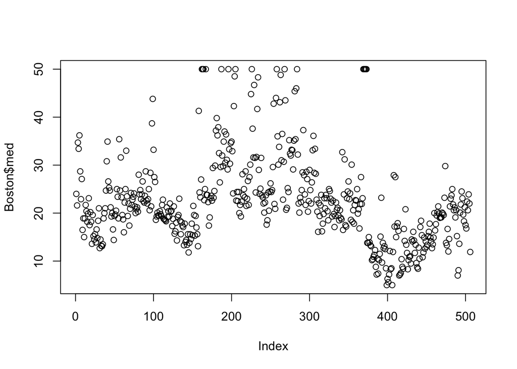

```r
plot(Boston$med)
```